# Movies Correlation Project

## Introduction

As my first Python project, I used the guidance of Alex the Analyst on Youtube for this project as well as adding on some of my own code (minimal at this stage until I learn more).

We are going to see if there is correlation within the data between the gross revenue of a film and any other aspect; the initial hypothesis is that gross revenue and budget will have a positive correlation.

## Process Data

### Set Up

I will now import the necessary libraries and load the relevant dataset for analysis.

```python
import pandas as pd
import seaborn as sns
import numpy as np

import matplotlib
import matplotlib.pyplot as plt
plt.style.use('ggplot')
from matplotlib.pyplot import figure

%matplotlib inline
matplotlib.rcParams['figure.figsize'] = (12, 8)

# Read in the data
import os

# List files in /kaggle/input directory and subdirectories
for dirname, _, filenames in os.walk('/kaggle/input'):
    for filename in filenames:
        print(os.path.join(dirname, filename))

# Read the CSV file using pandas
df = pd.read_csv('/kaggle/input/movies/movies.csv')

# Display the first few rows of the DataFrame
print(df.head())
```

```
/kaggle/input/movies/movies.csv
                                             name rating      genre  year  \
0                                     The Shining      R      Drama  1980
1                                 The Blue Lagoon      R  Adventure  1980
2  Star Wars: Episode V - The Empire Strikes Back     PG     Action  1980
3                                       Airplane!     PG     Comedy  1980
4                                      Caddyshack      R     Comedy  1980

                        released  score      votes         director  \
0  June 13, 1980 (United States)    8.4   927000.0  Stanley Kubrick
1   July 2, 1980 (United States)    5.8    65000.0   Randal Kleiser
2  June 20, 1980 (United States)    8.7  1200000.0   Irvin Kershner
3   July 2, 1980 (United States)    7.7   221000.0     Jim Abrahams
4  July 25, 1980 (United States)    7.3   108000.0     Harold Ramis

                    writer            star         country      budget  \
0             Stephen King  Jack Nicholson  United Kingdom  19000000.0
1  Henry De Vere Stacpoole  Brooke Shields   United States   4500000.0
2           Leigh Brackett     Mark Hamill   United States  18000000.0
3             Jim Abrahams     Robert Hays   United States   3500000.0
4       Brian Doyle-Murray     Chevy Chase   United States   6000000.0

         gross             company  runtime
0   46998772.0        Warner Bros.    146.0
1   58853106.0   Columbia Pictures    104.0
2  538375067.0           Lucasfilm    124.0
3   83453539.0  Paramount Pictures     88.0
4   39846344.0      Orion Pictures     98.0
```

### Clean & Transform Data

First, I will look for any missing data as a percentage

```python
# look for missing data

for col in df.columns:
    pct_missing = np.mean(df[col].isnull())
    print('{} - {}%'.format(col, pct_missing))
```

```
name - 0.0%
rating - 0.010041731872717789%
genre - 0.0%
year - 0.0%
released - 0.0002608242044861763%
score - 0.0003912363067292645%
votes - 0.0003912363067292645%
director - 0.0%
writer - 0.0003912363067292645%
star - 0.00013041210224308815%
country - 0.0003912363067292645%
budget - 0.2831246739697444%
gross - 0.02464788732394366%
company - 0.002217005738132499%
runtime - 0.0005216484089723526%
```

I will now remove any NA values as it will interfere with the analysis later on.

```python
df = df.dropna()
```

Now I want to see the structure of my data, to assess if any need reformatted/renamed/separated etc.

```python
# get structure of data

print(df.dtypes)
df.head()
```

```
name         object
rating       object
genre        object
year          int64
released     object
score       float64
votes       float64
director     object
writer       object
star         object
country      object
budget      float64
gross       float64
company      object
runtime     float64
dtype: object
```

|  | name | rating | genre | year | released | score | votes | director | writer | star | country | budget | gross | company | runtime |
| --- | --- | --- | --- | --- | --- | --- | --- | --- | --- | --- | --- | --- | --- | --- | --- |
| 0 | The Shining | R | Drama | 1980 | June 13, 1980 (United States) | 8.4 | 927000.0 | Stanley Kubrick | Stephen King | Jack Nicholson | United Kingdom | 19000000.0 | 46998772.0 | Warner Bros. | 146.0 |
| 1 | The Blue Lagoon | R | Adventure | 1980 | July 2, 1980 (United States) | 5.8 | 65000.0 | Randal Kleiser | Henry De Vere Stacpoole | Brooke Shields | United States | 4500000.0 | 58853106.0 | Columbia Pictures | 104.0 |
| 2 | Star Wars: Episode V - The Empire Strikes Back | PG | Action | 1980 | June 20, 1980 (United States) | 8.7 | 1200000.0 | Irvin Kershner | Leigh Brackett | Mark Hamill | United States | 18000000.0 | 538375067.0 | Lucasfilm | 124.0 |
| 3 | Airplane! | PG | Comedy | 1980 | July 2, 1980 (United States) | 7.7 | 221000.0 | Jim Abrahams | Jim Abrahams | Robert Hays | United States | 3500000.0 | 83453539.0 | Paramount Pictures | 88.0 |
| 4 | Caddyshack | R | Comedy | 1980 | July 25, 1980 (United States) | 7.3 | 108000.0 | Harold Ramis | Brian Doyle-Murray | Chevy Chase | United States | 6000000.0 | 39846344.0 | Orion Pictures | 98.0 |

### Filter

I note that "released" contains the date followed by "(United States)" afterwards, let's see if that's uniform throughout the data.

```python
# Filter rows where "released" column does not contain "(United States)"
released_filtered = df[~df['released'].str.contains("(United States)", regex=False)]

# Print the filtered rows
released_filtered.head()
```

|  | name | rating | genre | year | released | score | votes | director | writer | star | country | budget | gross | company | runtime |
| --- | --- | --- | --- | --- | --- | --- | --- | --- | --- | --- | --- | --- | --- | --- | --- |
| 129 | Cutter's Way | R | Crime | 1981 | February 10, 1982 (France) | 6.9 | 5300.0 | Ivan Passer | Newton Thornburg | Jeff Bridges | United States | 3000000.0 | 1752634.0 | Gurian Entertainment | 109.0 |
| 224 | The King of Comedy | PG | Comedy | 1982 | February 18, 1983 (Brazil) | 7.8 | 94000.0 | Martin Scorsese | Paul D. Zimmerman | Robert De Niro | United States | 20000000.0 | 2536242.0 | Embassy International Pictures | 109.0 |
| 231 | Fanny and Alexander | R | Drama | 1982 | December 17, 1982 (Sweden) | 8.1 | 59000.0 | Ingmar Bergman | Ingmar Bergman | Bertil Guve | Sweden | 6000000.0 | 6795771.0 | Cinematograph AB | 188.0 |
| 251 | The House on Sorority Row | R | Horror | 1982 | July 28, 1983 (South Korea) | 6.0 | 7800.0 | Mark Rosman | Mark Rosman | Kate McNeil | United States | 425000.0 | 10604986.0 | VAE Productions | 91.0 |
| 257 | Personal Best | R | Drama | 1982 | June 26, 1982 (Japan) | 6.3 | 2600.0 | Robert Towne | Robert Towne | Mariel Hemingway | United States | 16000000.0 | 5672311.0 | The Geffen Company | 128.0 |

### Separate

It's not all "United States", there are various different countries contained within this column alongside the date; let's separate them.

```python
# Extract release date and country using regex
df[['release_date', 'release_country']] = df['released'].str.extract(r'^(.*?)\s*\((.*?)\)$')

# Drop the original "released" column
df.drop(columns=['released'], inplace=True)
```

Let's see how that looks now.

```python
df.head()
```

|  | name | rating | genre | year | score | votes | director | writer | star | country | budget | gross | company | runtime | release_date | release_country |
| --- | --- | --- | --- | --- | --- | --- | --- | --- | --- | --- | --- | --- | --- | --- | --- | --- |
| 0 | The Shining | R | Drama | 1980 | 8.4 | 927000.0 | Stanley Kubrick | Stephen King | Jack Nicholson | United Kingdom | 19000000.0 | 46998772.0 | Warner Bros. | 146.0 | June 13, 1980 | United States |
| 1 | The Blue Lagoon | R | Adventure | 1980 | 5.8 | 65000.0 | Randal Kleiser | Henry De Vere Stacpoole | Brooke Shields | United States | 4500000.0 | 58853106.0 | Columbia Pictures | 104.0 | July 2, 1980 | United States |
| 2 | Star Wars: Episode V - The Empire Strikes Back | PG | Action | 1980 | 8.7 | 1200000.0 | Irvin Kershner | Leigh Brackett | Mark Hamill | United States | 18000000.0 | 538375067.0 | Lucasfilm | 124.0 | June 20, 1980 | United States |
| 3 | Airplane! | PG | Comedy | 1980 | 7.7 | 221000.0 | Jim Abrahams | Jim Abrahams | Robert Hays | United States | 3500000.0 | 83453539.0 | Paramount Pictures | 88.0 | July 2, 1980 | United States |
| 4 | Caddyshack | R | Comedy | 1980 | 7.3 | 108000.0 | Harold Ramis | Brian Doyle-Murray | Chevy Chase | United States | 6000000.0 | 39846344.0 | Orion Pictures | 98.0 | July 25, 1980 | United States |

```python
print(df.dtypes)
```

```
name                object
rating              object
genre               object
year                 int64
score              float64
votes              float64
director            object
writer              object
star                object
country             object
budget             float64
gross              float64
company             object
runtime            float64
release_date        object
release_country     object
dtype: object
```

I note that release_date is down as "object", let's convert that to date format.

```python
# Convert "release_date" to datetime format
df['release_date'] = pd.to_datetime(df['release_date'])


df.head()
```

|  | name | rating | genre | year | score | votes | director | writer | star | country | budget | gross | company | runtime | release_date | release_country |
| --- | --- | --- | --- | --- | --- | --- | --- | --- | --- | --- | --- | --- | --- | --- | --- | --- |
| 0 | The Shining | R | Drama | 1980 | 8.4 | 927000.0 | Stanley Kubrick | Stephen King | Jack Nicholson | United Kingdom | 19000000.0 | 46998772.0 | Warner Bros. | 146.0 | 1980-06-13 | United States |
| 1 | The Blue Lagoon | R | Adventure | 1980 | 5.8 | 65000.0 | Randal Kleiser | Henry De Vere Stacpoole | Brooke Shields | United States | 4500000.0 | 58853106.0 | Columbia Pictures | 104.0 | 1980-07-02 | United States |
| 2 | Star Wars: Episode V - The Empire Strikes Back | PG | Action | 1980 | 8.7 | 1200000.0 | Irvin Kershner | Leigh Brackett | Mark Hamill | United States | 18000000.0 | 538375067.0 | Lucasfilm | 124.0 | 1980-06-20 | United States |
| 3 | Airplane! | PG | Comedy | 1980 | 7.7 | 221000.0 | Jim Abrahams | Jim Abrahams | Robert Hays | United States | 3500000.0 | 83453539.0 | Paramount Pictures | 88.0 | 1980-07-02 | United States |
| 4 | Caddyshack | R | Comedy | 1980 | 7.3 | 108000.0 | Harold Ramis | Brian Doyle-Murray | Chevy Chase | United States | 6000000.0 | 39846344.0 | Orion Pictures | 98.0 | 1980-07-25 | United States |

Let's see what date range our data covers

```python
#find year range

min_date = df['release_date'].min()
max_date = df['release_date'].max()

# Calculate the range
range_date = max_date - min_date

# Print the range
print("Date Range:", range_date)
print("Min Date:", min_date)
print("Max Date:", max_date)
```

```
Date Range: 14825 days 00:00:00
Min Date: 1980-02-01 00:00:00
Max Date: 2020-09-03 00:00:00
```

So our Date range for Release Dates is 01/02/1980 to 03/09/2020; let's see if anything else needs cleaning.

```python
df.head()
```

[output not shown]

```python
df.dtypes
```

```
name                       object
rating                     object
genre                      object
year                        int64
score                     float64
votes                     float64
director                   object
writer                     object
star                       object
country                    object
budget                    float64
gross                     float64
company                    object
runtime                   float64
release_date       datetime64[ns]
release_country            object
dtype: object
```

### More Formatting

Some of the items are needlessly showing decimals, let's reformat to integers.

```python
# clean up decimals (float to int)

df['budget'] = df['budget'].astype('int64')
df['gross'] = df['gross'].astype('int64')
df['votes'] = df['votes'].astype('int64')
df['runtime'] = df['runtime'].astype('int64')
```

### Arrange / Sort

Let's sort our data by Gross Revenue in descending order, so we can clearly see which movie has produced the greatest revenue.

```python
df = df.sort_values(by=['gross'], inplace=False, ascending=False)

df.head()
```

|  | name | rating | genre | year | score | votes | director | writer | star | country | budget | gross | company | runtime | release_date | release_country |
| --- | --- | --- | --- | --- | --- | --- | --- | --- | --- | --- | --- | --- | --- | --- | --- | --- |
| 5445 | Avatar | PG-13 | Action | 2009 | 7.8 | 1100000 | James Cameron | James Cameron | Sam Worthington | United States | 237000000 | 2847246203 | Twentieth Century Fox | 162 | 2009-12-18 | United States |
| 7445 | Avengers: Endgame | PG-13 | Action | 2019 | 8.4 | 903000 | Anthony Russo | Christopher Markus | Robert Downey Jr. | United States | 356000000 | 2797501328 | Marvel Studios | 181 | 2019-04-26 | United States |
| 3045 | Titanic | PG-13 | Drama | 1997 | 7.8 | 1100000 | James Cameron | James Cameron | Leonardo DiCaprio | United States | 200000000 | 2201647264 | Twentieth Century Fox | 194 | 1997-12-19 | United States |
| 6663 | Star Wars: Episode VII - The Force Awakens | PG-13 | Action | 2015 | 7.8 | 876000 | J.J. Abrams | Lawrence Kasdan | Daisy Ridley | United States | 245000000 | 2069521700 | Lucasfilm | 138 | 2015-12-18 | United States |
| 7244 | Avengers: Infinity War | PG-13 | Action | 2018 | 8.4 | 897000 | Anthony Russo | Christopher Markus | Robert Downey Jr. | United States | 321000000 | 2048359754 | Marvel Studios | 149 | 2018-04-27 | United States |

```python
# Let's set it so we can see all of the set by scrolling if we wish.
pd.set_option('display.max_rows', None)
```

### Duplicates

```python
# drop duplicates

df['company'].drop_duplicates().sort_values(ascending=False)
# note: if we wanted to drop all dupes, just say this -> df.drop_duplicates()
```

```
7129                                              thefyzz
5664                                          micro_scope
4007                                             i5 Films
6793                                           i am OTHER
6420                                                 erbp
3776                                       double A Films
3330                          Zucker Brothers Productions
520                                      Zoetrope Studios
2213                                   Zeta Entertainment
3698                              Zentropa Entertainments
1180                                 Zenith Entertainment
5180                                      Zazen Produções
1321                             Zanuck/Brown Productions
1329                          Zacharias-Buhai Productions
789                             Young Sung Production Co.
```

[output cut: 1461 more lines]

```python
df.head()
```

|  | name | rating | genre | year | score | votes | director | writer | star | country | budget | gross | company | runtime | release_date | release_country |
| --- | --- | --- | --- | --- | --- | --- | --- | --- | --- | --- | --- | --- | --- | --- | --- | --- |
| 5445 | Avatar | PG-13 | Action | 2009 | 7.8 | 1100000 | James Cameron | James Cameron | Sam Worthington | United States | 237000000 | 2847246203 | Twentieth Century Fox | 162 | 2009-12-18 | United States |
| 7445 | Avengers: Endgame | PG-13 | Action | 2019 | 8.4 | 903000 | Anthony Russo | Christopher Markus | Robert Downey Jr. | United States | 356000000 | 2797501328 | Marvel Studios | 181 | 2019-04-26 | United States |
| 3045 | Titanic | PG-13 | Drama | 1997 | 7.8 | 1100000 | James Cameron | James Cameron | Leonardo DiCaprio | United States | 200000000 | 2201647264 | Twentieth Century Fox | 194 | 1997-12-19 | United States |
| 6663 | Star Wars: Episode VII - The Force Awakens | PG-13 | Action | 2015 | 7.8 | 876000 | J.J. Abrams | Lawrence Kasdan | Daisy Ridley | United States | 245000000 | 2069521700 | Lucasfilm | 138 | 2015-12-18 | United States |
| 7244 | Avengers: Infinity War | PG-13 | Action | 2018 | 8.4 | 897000 | Anthony Russo | Christopher Markus | Robert Downey Jr. | United States | 321000000 | 2048359754 | Marvel Studios | 149 | 2018-04-27 | United States |

## Analyse

### Hypothesis

The working hypothesis is as follows:

1. Budget and Gross will positively correlate as it would be thought that the more is spent on a film, the great cinematic experience and thus the greater return in revenue.

2. The Company will have a high correlation with the amount of budget; this is my thoughts as bigger companies such as Warner Bros etc would generally have more budget to play with than smaller companies.

## Visualize

Let's run scatter plots and see.

```
<function matplotlib.pyplot.show(close=None, block=None)>
```

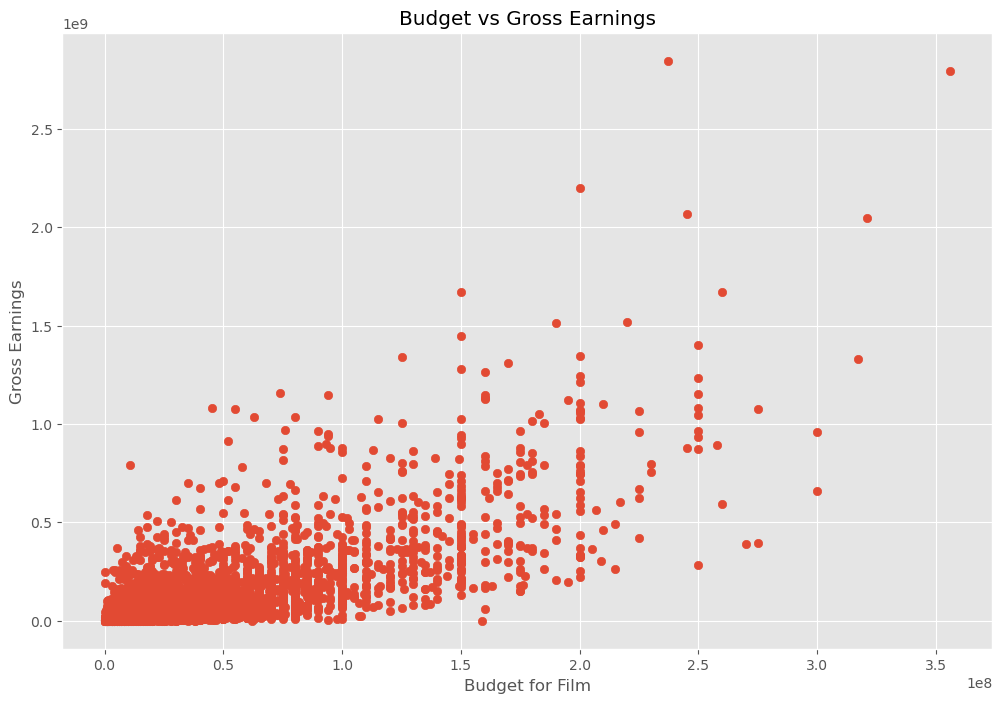

```python
# scatter plot with budget vs gross

plt.scatter(x=df['budget'], y=df['gross'])

plt.title('Budget vs Gross Earnings')

plt.xlabel('Budget for Film')
plt.ylabel('Gross Earnings')
plt.show
```

```python
df.head()
```

|  | name | rating | genre | year | score | votes | director | writer | star | country | budget | gross | company | runtime | release_date | release_country |
| --- | --- | --- | --- | --- | --- | --- | --- | --- | --- | --- | --- | --- | --- | --- | --- | --- |
| 5445 | Avatar | PG-13 | Action | 2009 | 7.8 | 1100000 | James Cameron | James Cameron | Sam Worthington | United States | 237000000 | 2847246203 | Twentieth Century Fox | 162 | 2009-12-18 | United States |
| 7445 | Avengers: Endgame | PG-13 | Action | 2019 | 8.4 | 903000 | Anthony Russo | Christopher Markus | Robert Downey Jr. | United States | 356000000 | 2797501328 | Marvel Studios | 181 | 2019-04-26 | United States |
| 3045 | Titanic | PG-13 | Drama | 1997 | 7.8 | 1100000 | James Cameron | James Cameron | Leonardo DiCaprio | United States | 200000000 | 2201647264 | Twentieth Century Fox | 194 | 1997-12-19 | United States |
| 6663 | Star Wars: Episode VII - The Force Awakens | PG-13 | Action | 2015 | 7.8 | 876000 | J.J. Abrams | Lawrence Kasdan | Daisy Ridley | United States | 245000000 | 2069521700 | Lucasfilm | 138 | 2015-12-18 | United States |
| 7244 | Avengers: Infinity War | PG-13 | Action | 2018 | 8.4 | 897000 | Anthony Russo | Christopher Markus | Robert Downey Jr. | United States | 321000000 | 2048359754 | Marvel Studios | 149 | 2018-04-27 | United States |

It looks like there's a positive correlation, let's add a line into the plot and see.

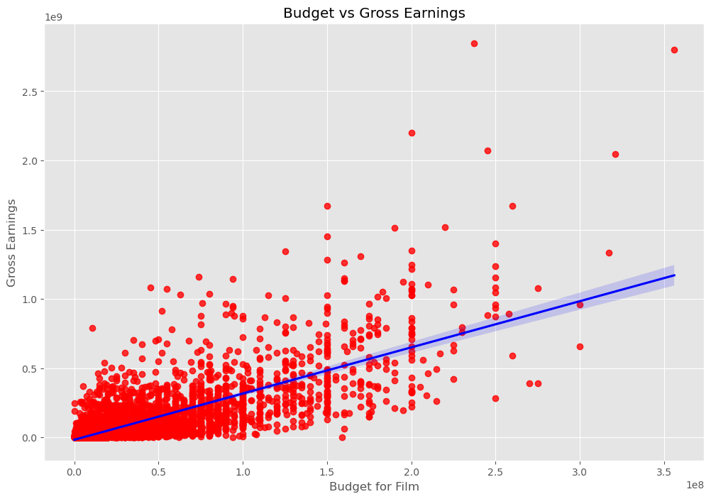

```python
# plot budget vs gross using seaborn

sns.regplot(x='budget', y='gross', data=df, scatter_kws={"color": "red"}, line_kws={"color":"blue"})

plt.title('Budget vs Gross Earnings')

plt.xlabel('Budget for Film')
plt.ylabel('Gross Earnings')
plt.show

# Save the plot as an image file
plt.savefig('chart_budget_gross.png')
```

The correlation is a bit more clear now but let's check for the mathmatical output of correlation against all numerical values in our data using the pearson method.

```python
# determine the correlation

df.corr(method='pearson') #pearson, kendall, spearman correlation are the three methods, so each will provide a slightly different result.
```

|  | year | score | votes | budget | gross | runtime |
| --- | --- | --- | --- | --- | --- | --- |
| year | 1.000000 | 0.056386 | 0.206021 | 0.327722 | 0.274321 | 0.075077 |
| score | 0.056386 | 1.000000 | 0.474256 | 0.072001 | 0.222556 | 0.414068 |
| votes | 0.206021 | 0.474256 | 1.000000 | 0.439675 | 0.614751 | 0.352303 |
| budget | 0.327722 | 0.072001 | 0.439675 | 1.000000 | 0.740247 | 0.318695 |
| gross | 0.274321 | 0.222556 | 0.614751 | 0.740247 | 1.000000 | 0.275796 |
| runtime | 0.075077 | 0.414068 | 0.352303 | 0.318695 | 0.275796 | 1.000000 |

From this, we can see a high correlation between budget and gross, closely followed by votes and gross.

## Visualization

Let's visualize it into a heat map for ease.

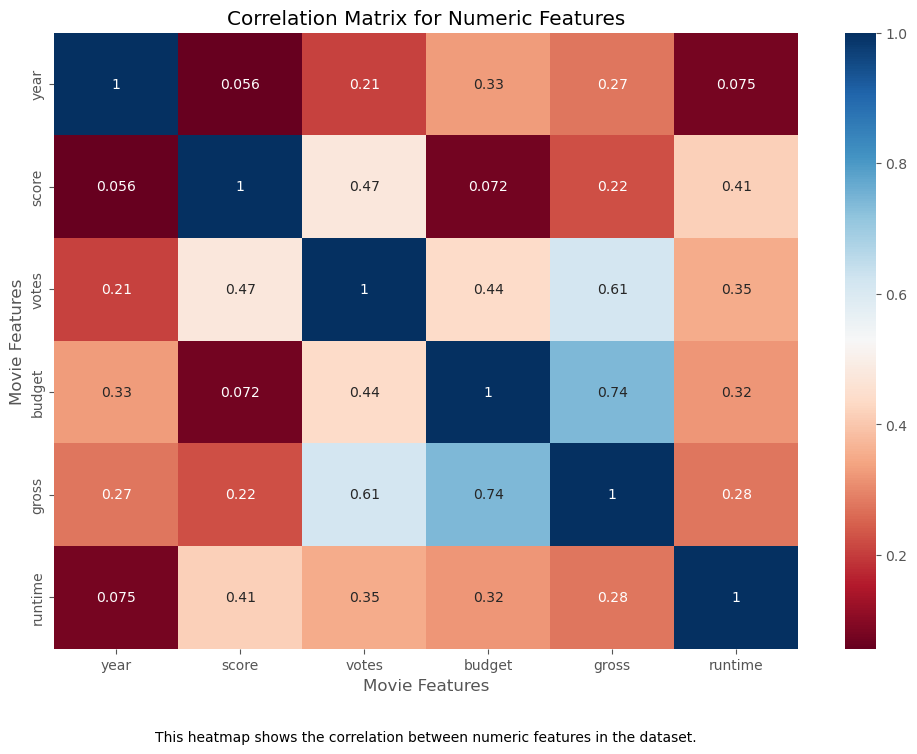

```python
# let's name the above correlation grid

cor_matrix = df.corr(method='pearson')

# now create the heatmap
sns.heatmap(cor_matrix, annot=True, cmap='RdBu') # Use 'RdBu_r' for reverse color scale, use 'RdYlGn' for red, yellow, green

plt.title('Correlation Matrix for Numeric Features')

plt.xlabel('Movie Features')
plt.ylabel('Movie Features')
caption = "This heatmap shows the correlation between numeric features in the dataset."
plt.annotate(caption, xy=(0.5, -0.15), xycoords='axes fraction', ha='center', fontsize=10)

plt.show()

# save it
plt.savefig('cor_heatmap_1.png', bbox_inches='tight')
```

## Analyse

Another hypothesis was that the Company itself would correlate to the budget, but Company is not a numeric so cannot be included in the calculation in this state. Let's apply numeric values to everything that presents as an object, but save it as a separate data frame so to protect the original.

```python
# apply numeric value to copied dataframe

df_numeric = df.copy()

for col_name in df_numeric.columns:
    if(df_numeric[col_name].dtype == 'object'):
        df_numeric[col_name] = df_numeric[col_name].astype('category')
        df_numeric[col_name] = df_numeric[col_name].cat.codes

df_numeric.head()
```

|  | name | rating | genre | year | score | votes | director | writer | star | country | budget | gross | company | runtime | release_date | release_country |
| --- | --- | --- | --- | --- | --- | --- | --- | --- | --- | --- | --- | --- | --- | --- | --- | --- |
| 5445 | 386 | 5 | 0 | 2009 | 7.8 | 1100000 | 785 | 1263 | 1534 | 47 | 237000000 | 2847246203 | 1382 | 162 | 2009-12-18 | 47 |
| 7445 | 388 | 5 | 0 | 2019 | 8.4 | 903000 | 105 | 513 | 1470 | 47 | 356000000 | 2797501328 | 983 | 181 | 2019-04-26 | 47 |
| 3045 | 4909 | 5 | 6 | 1997 | 7.8 | 1100000 | 785 | 1263 | 1073 | 47 | 200000000 | 2201647264 | 1382 | 194 | 1997-12-19 | 47 |
| 6663 | 3643 | 5 | 0 | 2015 | 7.8 | 876000 | 768 | 1806 | 356 | 47 | 245000000 | 2069521700 | 945 | 138 | 2015-12-18 | 47 |
| 7244 | 389 | 5 | 0 | 2018 | 8.4 | 897000 | 105 | 513 | 1470 | 47 | 321000000 | 2048359754 | 983 | 149 | 2018-04-27 | 47 |

```python
df.head()
```

|  | name | rating | genre | year | score | votes | director | writer | star | country | budget | gross | company | runtime | release_date | release_country |
| --- | --- | --- | --- | --- | --- | --- | --- | --- | --- | --- | --- | --- | --- | --- | --- | --- |
| 5445 | Avatar | PG-13 | Action | 2009 | 7.8 | 1100000 | James Cameron | James Cameron | Sam Worthington | United States | 237000000 | 2847246203 | Twentieth Century Fox | 162 | 2009-12-18 | United States |
| 7445 | Avengers: Endgame | PG-13 | Action | 2019 | 8.4 | 903000 | Anthony Russo | Christopher Markus | Robert Downey Jr. | United States | 356000000 | 2797501328 | Marvel Studios | 181 | 2019-04-26 | United States |
| 3045 | Titanic | PG-13 | Drama | 1997 | 7.8 | 1100000 | James Cameron | James Cameron | Leonardo DiCaprio | United States | 200000000 | 2201647264 | Twentieth Century Fox | 194 | 1997-12-19 | United States |
| 6663 | Star Wars: Episode VII - The Force Awakens | PG-13 | Action | 2015 | 7.8 | 876000 | J.J. Abrams | Lawrence Kasdan | Daisy Ridley | United States | 245000000 | 2069521700 | Lucasfilm | 138 | 2015-12-18 | United States |
| 7244 | Avengers: Infinity War | PG-13 | Action | 2018 | 8.4 | 897000 | Anthony Russo | Christopher Markus | Robert Downey Jr. | United States | 321000000 | 2048359754 | Marvel Studios | 149 | 2018-04-27 | United States |

By looking at the heads of the two data frames side by side, we can see that this appears to have worked.

Let's plot another heat map with the new information from the copied data frame.

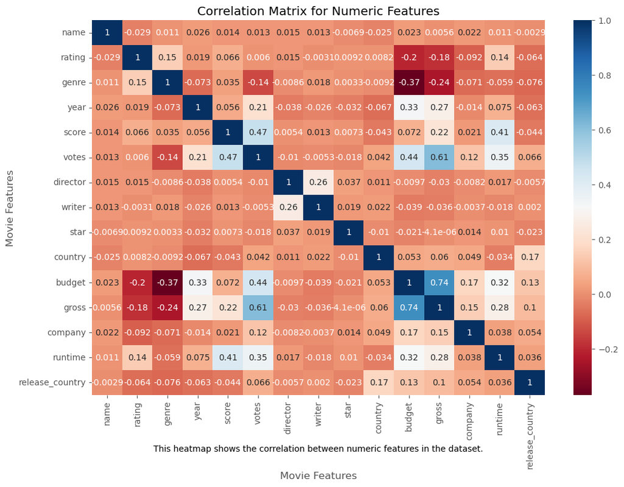

```python
# Calculate the correlation with the new numeric values included
cor_numeric = df_numeric.corr(method='pearson')

# plot a heatmap
sns.heatmap(cor_numeric, annot=True, cmap='RdBu') # Use 'RdBu_r' for reverse color scale, use 'RdYlGn' for red, yellow, green

plt.title('Correlation Matrix for Numeric Features')

plt.xlabel('Movie Features')
plt.ylabel('Movie Features')
caption = "This heatmap shows the correlation between numeric features in the dataset."
plt.annotate(caption, xy=(0.5, -0.15), xycoords='axes fraction', ha='center', fontsize=10)

plt.show()

# save it
plt.savefig('cor_heatmap_2.png', bbox_inches='tight')
```

Let's also run the grid from earlier but with the new numeric values included.

```python
df_numeric.corr()
```

|  | name | rating | genre | year | score | votes | director | writer | star | country | budget | gross | company | runtime | release_country |
| --- | --- | --- | --- | --- | --- | --- | --- | --- | --- | --- | --- | --- | --- | --- | --- |
| name | 1.000000 | -0.029234 | 0.010996 | 0.025542 | 0.014450 | 0.012615 | 0.015246 | 0.012880 | -0.006882 | -0.025490 | 0.023392 | 0.005639 | 0.021697 | 0.010850 | -0.002908 |
| rating | -0.029234 | 1.000000 | 0.147796 | 0.019499 | 0.065983 | 0.006031 | 0.014656 | -0.003149 | 0.009196 | 0.008230 | -0.203946 | -0.181906 | -0.092357 | 0.140792 | -0.063883 |
| genre | 0.010996 | 0.147796 | 1.000000 | -0.073167 | 0.035106 | -0.135990 | -0.008553 | 0.017578 | 0.003341 | -0.009164 | -0.368523 | -0.244101 | -0.071334 | -0.059237 | -0.075552 |
| year | 0.025542 | 0.019499 | -0.073167 | 1.000000 | 0.056386 | 0.206021 | -0.038354 | -0.025908 | -0.032157 | -0.066748 | 0.327722 | 0.274321 | -0.014333 | 0.075077 | -0.062768 |
| score | 0.014450 | 0.065983 | 0.035106 | 0.056386 | 1.000000 | 0.474256 | 0.005413 | 0.012843 | 0.007296 | -0.043051 | 0.072001 | 0.222556 | 0.020656 | 0.414068 | -0.043528 |
| votes | 0.012615 | 0.006031 | -0.135990 | 0.206021 | 0.474256 | 1.000000 | -0.010376 | -0.005316 | -0.017638 | 0.041551 | 0.439675 | 0.614751 | 0.118470 | 0.352303 | 0.066105 |
| director | 0.015246 | 0.014656 | -0.008553 | -0.038354 | 0.005413 | -0.010376 | 1.000000 | 0.261735 | 0.036593 | 0.011133 | -0.009662 | -0.029560 | -0.008223 | 0.017433 | -0.005705 |
| writer | 0.012880 | -0.003149 | 0.017578 | -0.025908 | 0.012843 | -0.005316 | 0.261735 | 1.000000 | 0.018520 | 0.022488 | -0.039466 | -0.035885 | -0.003697 | -0.017561 | 0.001983 |
| star | -0.006882 | 0.009196 | 0.003341 | -0.032157 | 0.007296 | -0.017638 | 0.036593 | 0.018520 | 1.000000 | -0.009990 | -0.021473 | -0.000004 | 0.014082 | 0.010108 | -0.023346 |
| country | -0.025490 | 0.008230 | -0.009164 | -0.066748 | -0.043051 | 0.041551 | 0.011133 | 0.022488 | -0.009990 | 1.000000 | 0.052977 | 0.060078 | 0.048569 | -0.034477 | 0.167894 |
| budget | 0.023392 | -0.203946 | -0.368523 | 0.327722 | 0.072001 | 0.439675 | -0.009662 | -0.039466 | -0.021473 | 0.052977 | 1.000000 | 0.740247 | 0.170235 | 0.318695 | 0.126976 |
| gross | 0.005639 | -0.181906 | -0.244101 | 0.274321 | 0.222556 | 0.614751 | -0.029560 | -0.035885 | -0.000004 | 0.060078 | 0.740247 | 1.000000 | 0.149553 | 0.275796 | 0.100029 |
| company | 0.021697 | -0.092357 | -0.071334 | -0.014333 | 0.020656 | 0.118470 | -0.008223 | -0.003697 | 0.014082 | 0.048569 | 0.170235 | 0.149553 | 1.000000 | 0.037585 | 0.054484 |
| runtime | 0.010850 | 0.140792 | -0.059237 | 0.075077 | 0.414068 | 0.352303 | 0.017433 | -0.017561 | 0.010108 | -0.034477 | 0.318695 | 0.275796 | 0.037585 | 1.000000 | 0.036272 |
| release_country | -0.002908 | -0.063883 | -0.075552 | -0.062768 | -0.043528 | 0.066105 | -0.005705 | 0.001983 | -0.023346 | 0.167894 | 0.126976 | 0.100029 | 0.054484 | 0.036272 | 1.000000 |

Let's unstack them into pairs for ease of reading and analysis.

### Unstack and Pair

```python
# unstack

cor_mat = df_numeric.corr()

cor_pairs = cor_mat.unstack()

cor_pairs
```

```
name             name               1.000000
                 rating            -0.029234
                 genre              0.010996
                 year               0.025542
                 score              0.014450
                 votes              0.012615
                 director           0.015246
                 writer             0.012880
                 star              -0.006882
                 country           -0.025490
                 budget             0.023392
                 gross              0.005639
                 company            0.021697
                 runtime            0.010850
                 release_country   -0.002908
rating           name              -0.029234
                 rating             1.000000
                 genre              0.147796
                 year               0.019499
                 score              0.065983
                 votes              0.006031
                 director           0.014656
                 writer            -0.003149
                 star               0.009196
                 country            0.008230
                 budget            -0.203946
                 gross             -0.181906
                 company           -0.092357
                 runtime            0.140792
                 release_country   -0.063883
genre            name               0.010996
                 rating             0.147796
                 genre              1.000000
                 year              -0.073167
                 score              0.035106
                 votes             -0.135990
                 director          -0.008553
                 writer             0.017578
                 star               0.003341
                 country           -0.009164
```

[output cut: 171 more lines]

```
                 rating            -0.063883
                 genre             -0.075552
                 year              -0.062768
                 score             -0.043528
                 votes              0.066105
                 director          -0.005705
                 writer             0.001983
                 star              -0.023346
                 country            0.167894
                 budget             0.126976
                 gross              0.100029
                 company            0.054484
                 runtime            0.036272
                 release_country    1.000000
dtype: float64
```

### Sort

Let's add a sort clause to make it easier again to read and analyse.

```python
cor_pairs_sorted = cor_pairs.sort_values()

cor_pairs_sorted
```

```
genre            budget            -0.368523
budget           genre             -0.368523
gross            genre             -0.244101
genre            gross             -0.244101
budget           rating            -0.203946
rating           budget            -0.203946
                 gross             -0.181906
gross            rating            -0.181906
votes            genre             -0.135990
genre            votes             -0.135990
company          rating            -0.092357
rating           company           -0.092357
genre            release_country   -0.075552
release_country  genre             -0.075552
genre            year              -0.073167
year             genre             -0.073167
genre            company           -0.071334
company          genre             -0.071334
year             country           -0.066748
country          year              -0.066748
rating           release_country   -0.063883
release_country  rating            -0.063883
                 year              -0.062768
year             release_country   -0.062768
runtime          genre             -0.059237
genre            runtime           -0.059237
release_country  score             -0.043528
score            release_country   -0.043528
country          score             -0.043051
score            country           -0.043051
budget           writer            -0.039466
writer           budget            -0.039466
year             director          -0.038354
director         year              -0.038354
gross            writer            -0.035885
writer           gross             -0.035885
country          runtime           -0.034477
runtime          country           -0.034477
year             star              -0.032157
star             year              -0.032157
```

[output cut: 171 more lines]

```
writer           writer             1.000000
company          company            1.000000
gross            gross              1.000000
budget           budget             1.000000
country          country            1.000000
star             star               1.000000
director         director           1.000000
votes            votes              1.000000
score            score              1.000000
year             year               1.000000
genre            genre              1.000000
rating           rating             1.000000
runtime          runtime            1.000000
release_country  release_country    1.000000
dtype: float64
```

### Filter

Now let's only show those with a correlation factor of more than 0.5

```python
high_cor = cor_pairs_sorted[(cor_pairs_sorted) > 0.5]

high_cor
```

```
gross            votes              0.614751
votes            gross              0.614751
budget           gross              0.740247
gross            budget             0.740247
name             name               1.000000
writer           writer             1.000000
company          company            1.000000
gross            gross              1.000000
budget           budget             1.000000
country          country            1.000000
star             star               1.000000
director         director           1.000000
votes            votes              1.000000
score            score              1.000000
year             year               1.000000
genre            genre              1.000000
rating           rating             1.000000
runtime          runtime            1.000000
release_country  release_country    1.000000
dtype: float64
```

# Conclusion

We can see that company name actually has a fairly low correlation with the budget but we have confirmed that budget and gross are fairly highly correlated.

We also discovered that Votes and Gross were an additional highly correlated pairing, which makes sense as the amount of money made on a movie would liekly lead to it receiving higher votes.